# Análisis de datos ambientales

# Descomposición de serie temporal mensual para la estación 60, Plaza Tres Olivos.

Se trata de una estación de tipo “Urbana Fondo”. Hemos representado sus respectivos parámetros que son Dióxido de nitrógeno (8), Particulas <10um (10), Ozono (14).

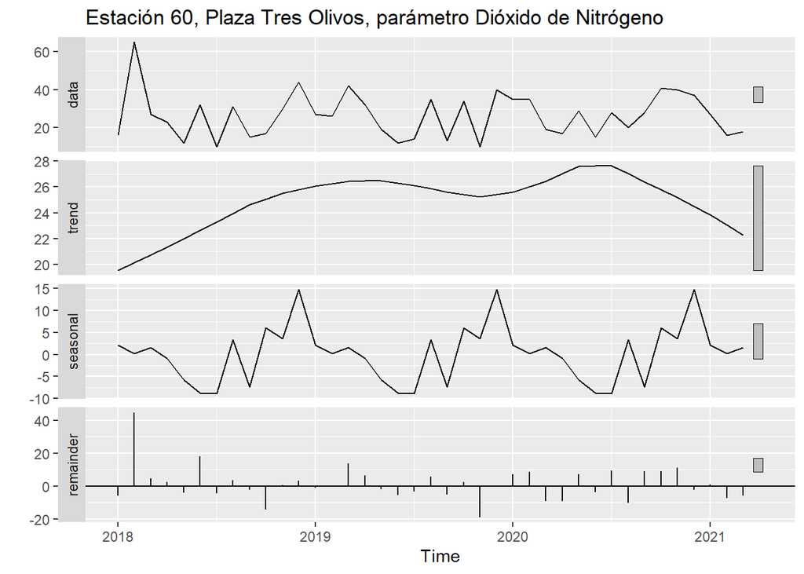

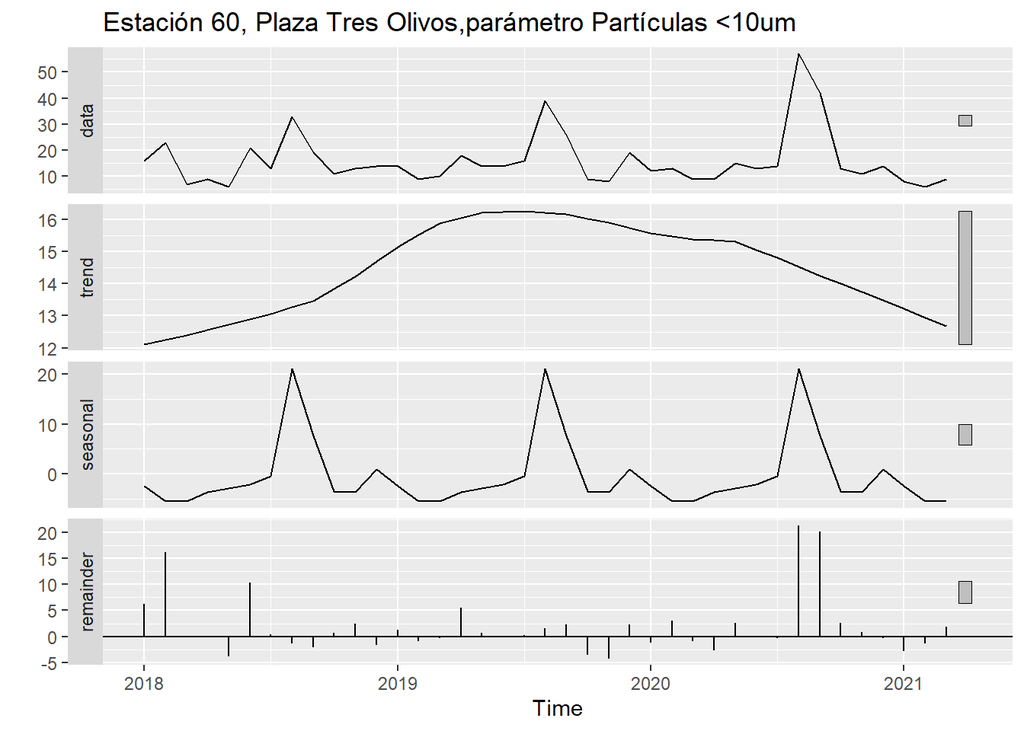

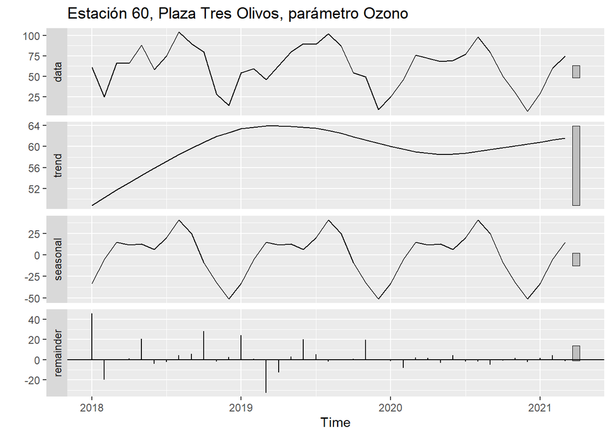

# Descomposición de serie temporal diaria para la estación 8, Escuelas Aguirre.

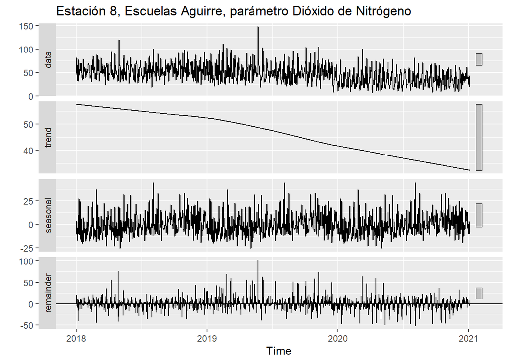

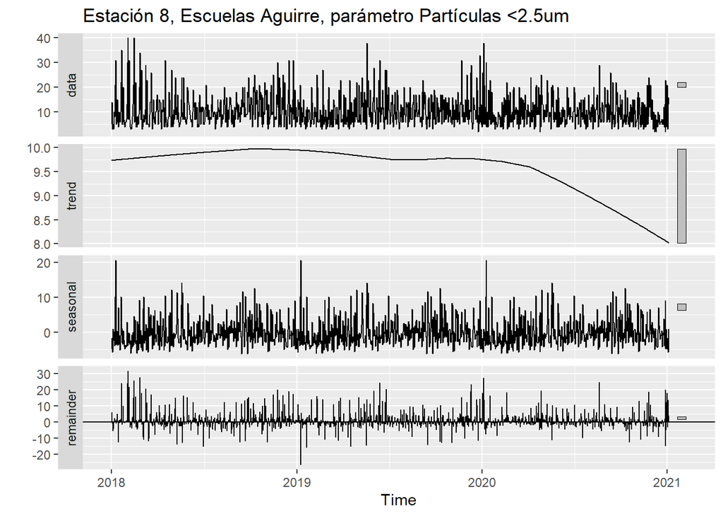

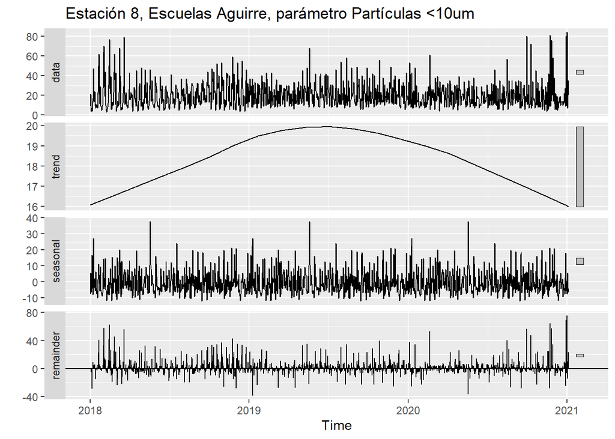

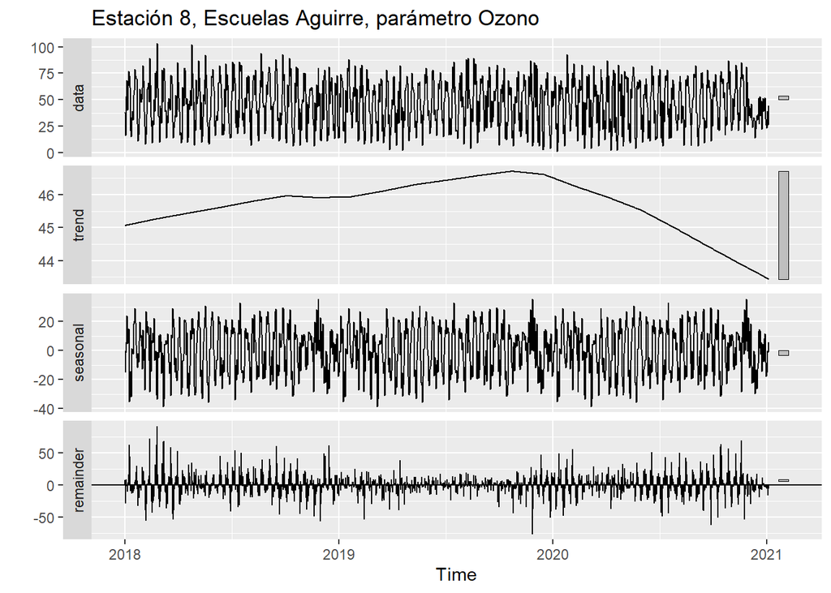

# Descomposición de serie temporal diaria para la estación 24, Casa Campo.

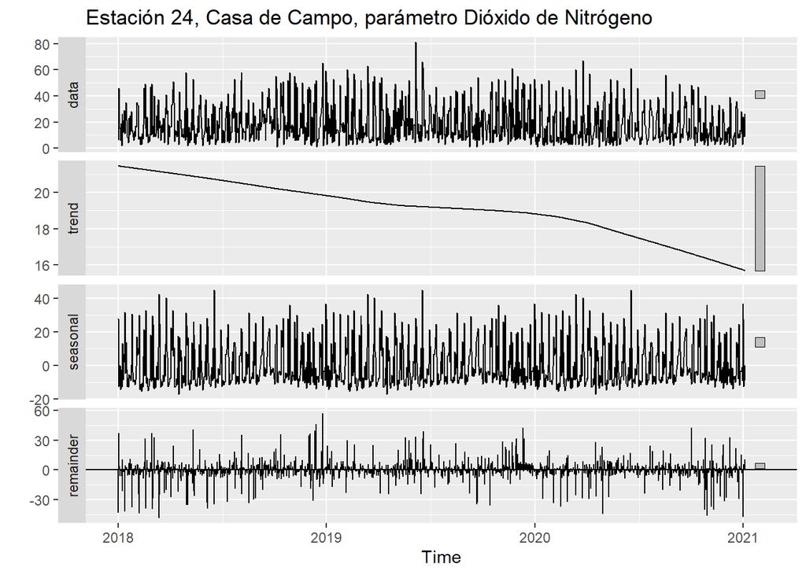

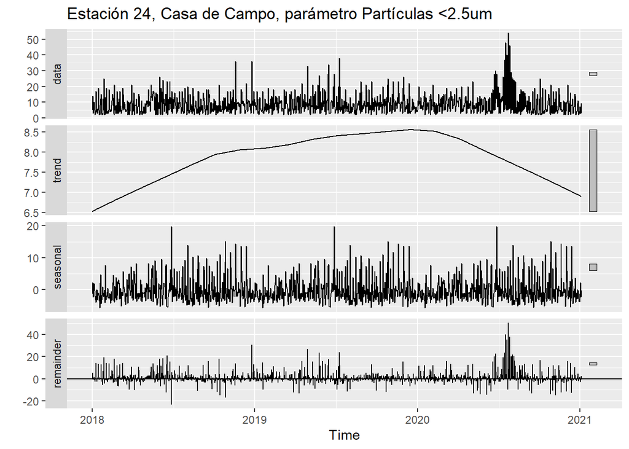

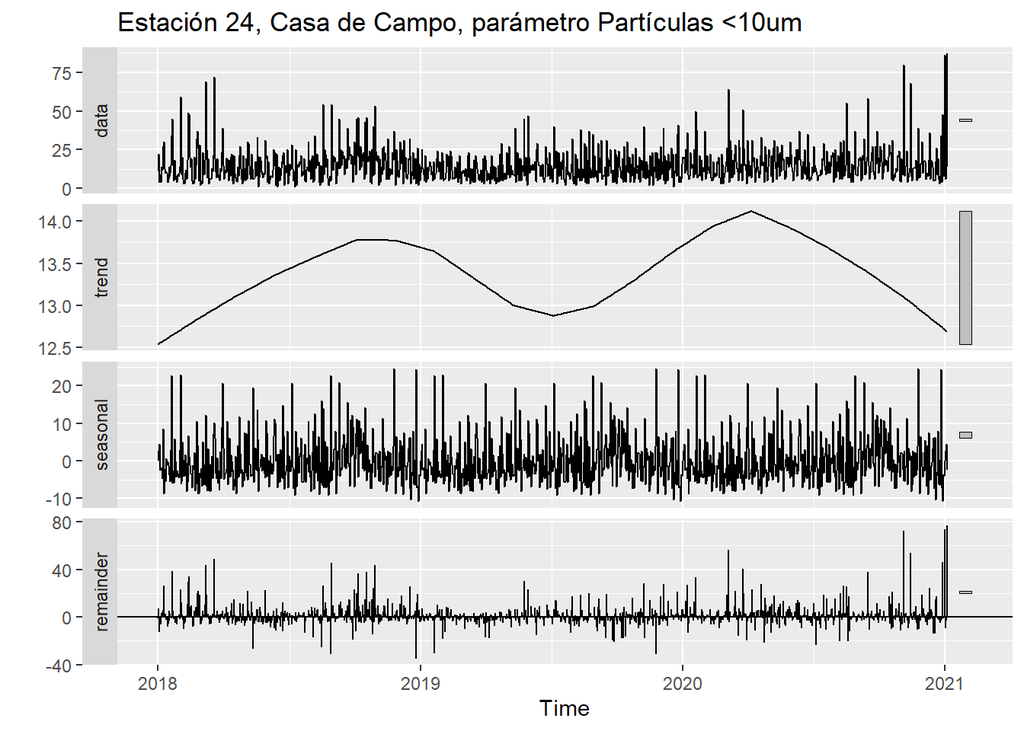

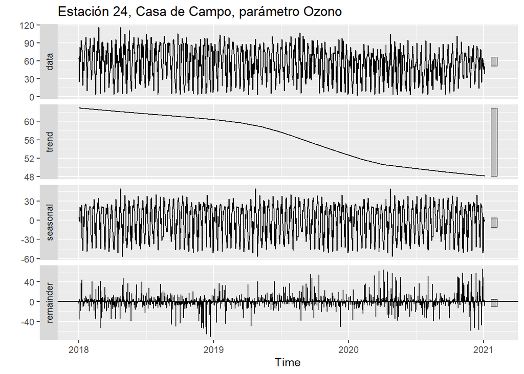

# Descomposición de serie temporal diaria para la estación 60, Plaza Tres Olivos.

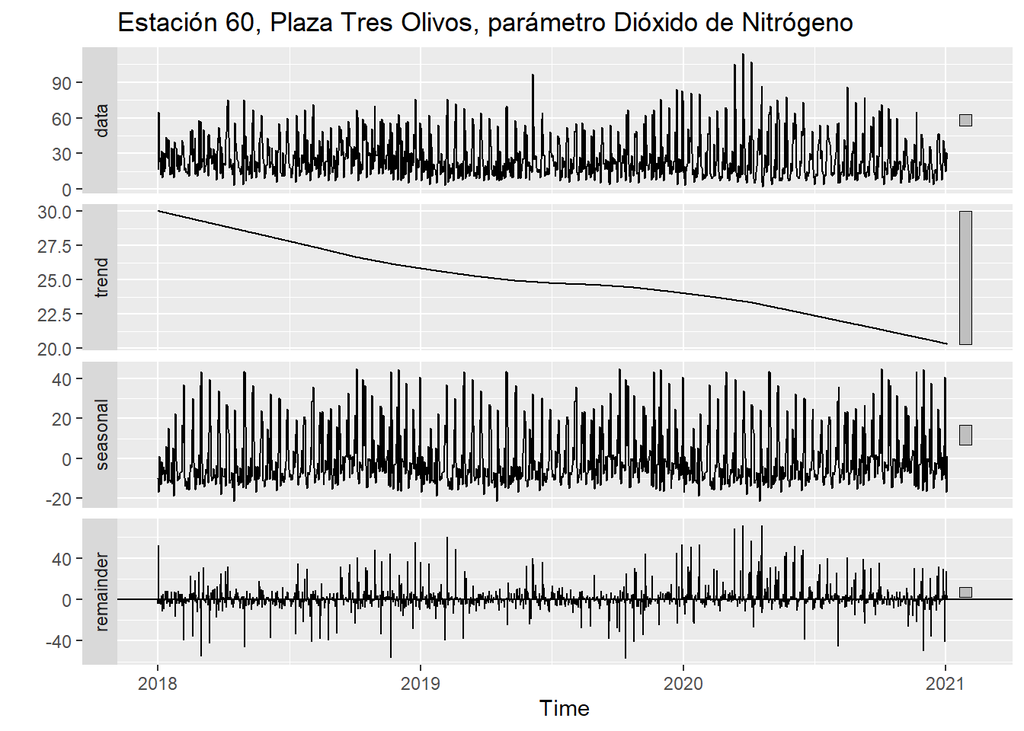

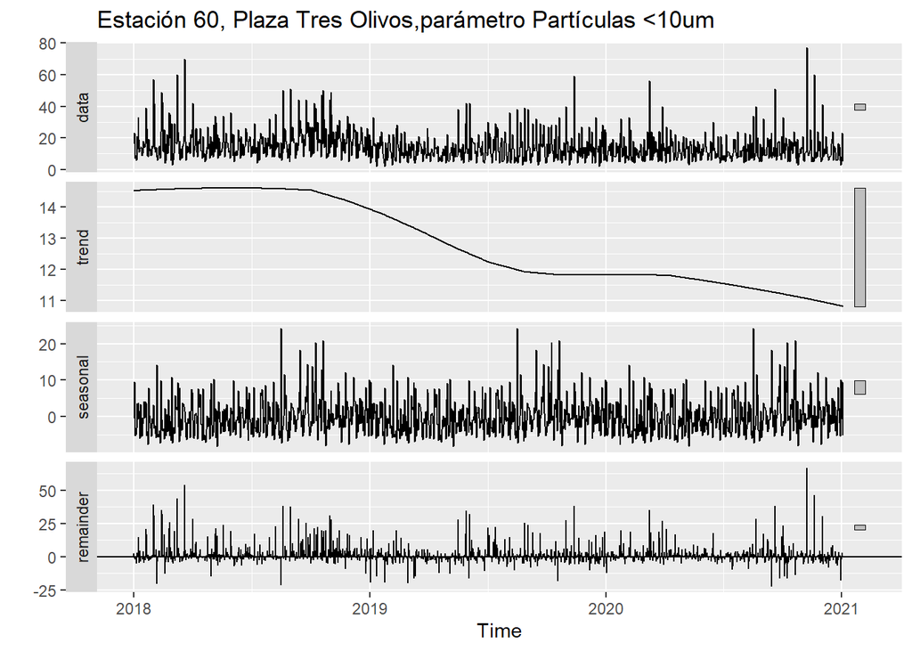

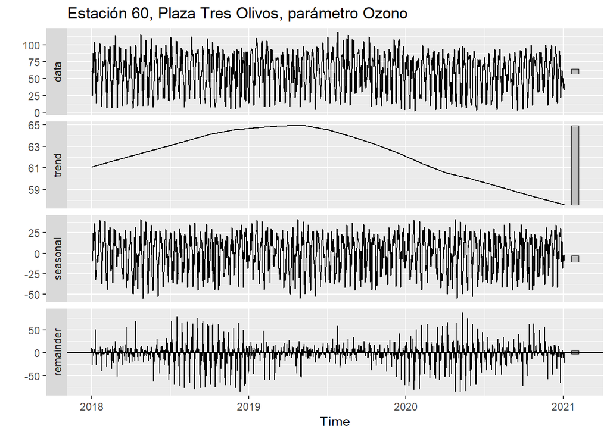

# Modelos ARIMA

### Series temporales de la estación 60 que se predicirán: magnitud 8= Dioxido de Nitrógeno, magnitud 10=Particulas<10, magnitud 14=ozono

### Elaboramos el modelo magnitud 8, Dióxido de nitrógeno, en la estación 60

```
##
##  ARIMA(2,0,2)(1,0,1)[12] with non-zero mean : Inf
##  ARIMA(0,0,0)            with non-zero mean : 306.5716
##  ARIMA(1,0,0)(1,0,0)[12] with non-zero mean : 310.8688
##  ARIMA(0,0,1)(0,0,1)[12] with non-zero mean : 310.917
##  ARIMA(0,0,0)            with zero mean     : 375.1432
##  ARIMA(0,0,0)(1,0,0)[12] with non-zero mean : 308.5791
##  ARIMA(0,0,0)(0,0,1)[12] with non-zero mean : 308.602
##  ARIMA(0,0,0)(1,0,1)[12] with non-zero mean : 311.0673
##  ARIMA(1,0,0)            with non-zero mean : 308.8182
##  ARIMA(0,0,1)            with non-zero mean : 308.8284
##  ARIMA(1,0,1)            with non-zero mean : 309.434
##
##  Best model: ARIMA(0,0,0)            with non-zero mean
```

```
## Series: tss_60_8
## ARIMA(0,0,0) with non-zero mean
##
## Coefficients:
##          mean
##       26.4359
## s.e.   1.8666
##
## sigma^2 estimated as 139.5:  log likelihood=-151.12
## AIC=306.24   AICc=306.57   BIC=309.57
##
## Training set error measures:
##                        ME     RMSE      MAE       MPE     MAPE      MASE
## Training set 1.585092e-14 11.65705 9.428008 -22.50909 45.66365 0.7667356
##                     ACF1
## Training set -0.05178635
##                        ME     RMSE      MAE       MPE     MAPE      MASE
## Training set 1.585092e-14 11.65705 9.428008 -22.50909 45.66365 0.7667356
##                     ACF1
## Training set -0.05178635
```

### Realizamos predicciones magnitud 8, Dióxido de nitrógeno, en la estación 60

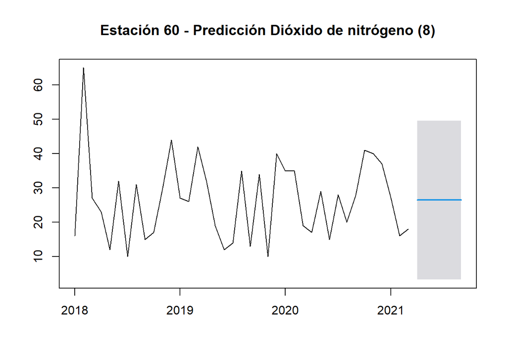

```
##
## Forecast method: ARIMA(0,0,0) with non-zero mean
##
## Model Information:
## Series: tss_60_8
## ARIMA(0,0,0) with non-zero mean
##
## Coefficients:
##          mean
##       26.4359
## s.e.   1.8666
##
## sigma^2 estimated as 139.5:  log likelihood=-151.12
## AIC=306.24   AICc=306.57   BIC=309.57
##
## Error measures:
##                        ME     RMSE      MAE       MPE     MAPE      MASE
## Training set 1.585092e-14 11.65705 9.428008 -22.50909 45.66365 0.7667356
##                     ACF1
## Training set -0.05178635
##
## Forecasts:
##          Point Forecast    Lo 95    Hi 95
## Apr 2021        26.4359 3.289819 49.58198
## May 2021        26.4359 3.289819 49.58198
## Jun 2021        26.4359 3.289819 49.58198
## Jul 2021        26.4359 3.289819 49.58198
## Aug 2021        26.4359 3.289819 49.58198
## Sep 2021        26.4359 3.289819 49.58198
```

### Realizamos nuevo filtrado de fecha para separar la serie de Dióxido de Nitrógeno: guardamos sólo los datos desde Marzo de 2018 hasta Marzo 2020

### Construcción de las series desde Marzo de 2018 hasta Marzo de 2020, utilizamos dos años completos.

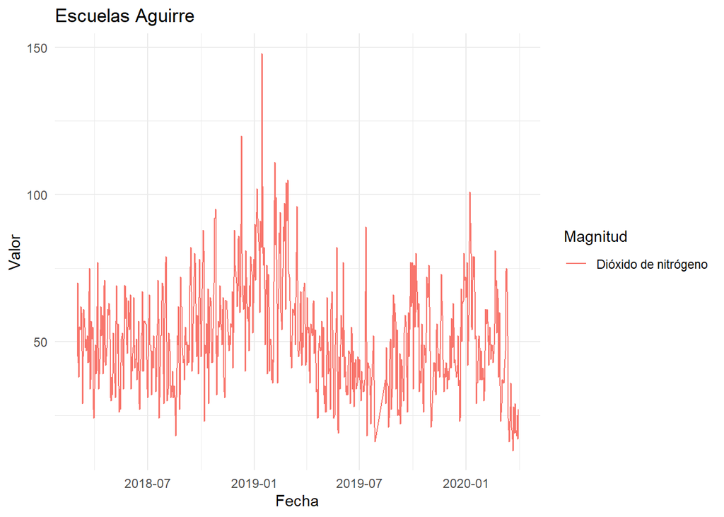

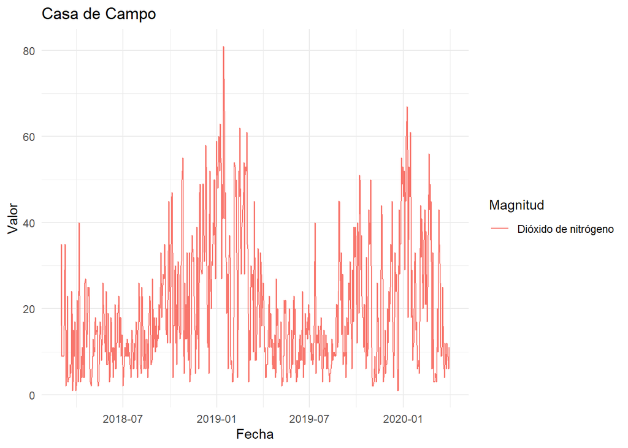

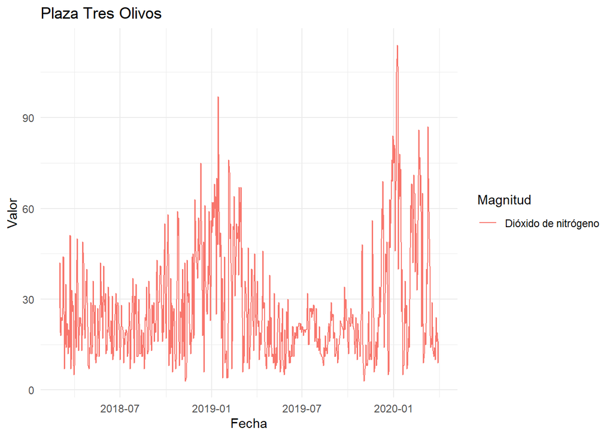

```r
puntos5<- unique(df2$nombre_estacion)

for (punto in puntos5){

muestra_2 <- df2%>% filter(nombre_estacion==punto & magnitud == 8)


plot <- ggplot(muestra_2, aes(x=fecha, y=valor)) +
  geom_line(aes(col=as.factor(nombre_magnitud)))+ theme_minimal()+ ggtitle(punto)+
  xlab("Fecha")+ylab("Valor")+labs(color="Magnitud")
print(plot)
}
```

### Descomposición de los datos de marzo 2018 - marzo 2020

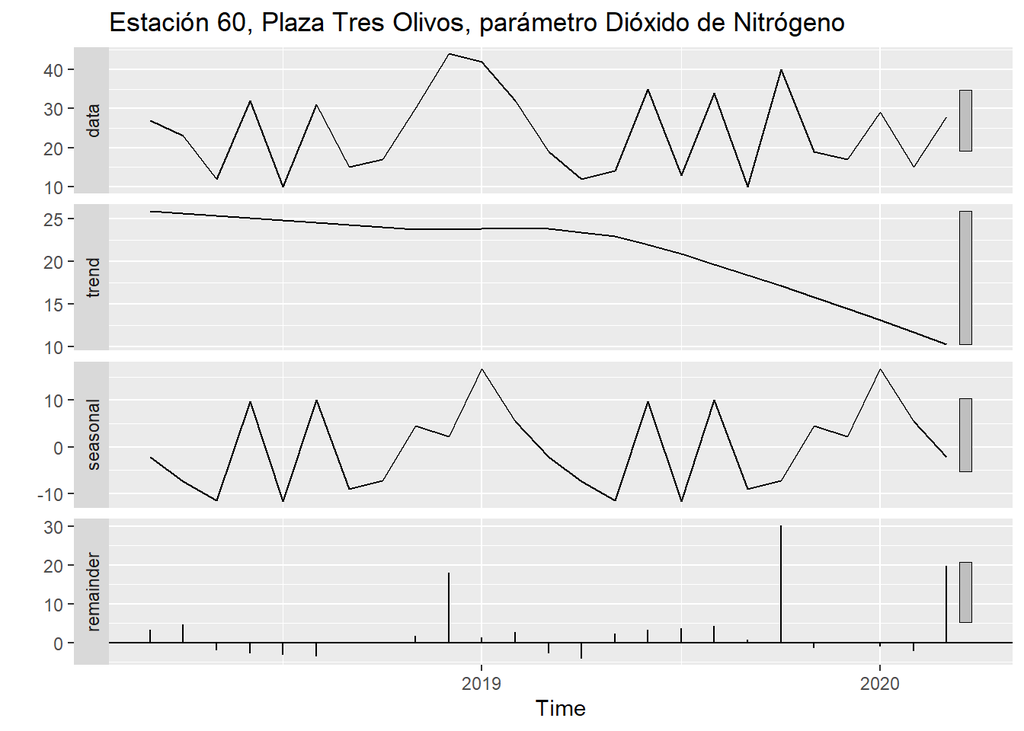

### Elaboramos el modelo magnitud 8, Dióxido de nitrógeno, en la estación 60

```
##
##  ARIMA(2,0,2)(0,1,0)[12] with drift         : Inf
##  ARIMA(0,0,0)(0,1,0)[12] with drift         : 23.81784
##  ARIMA(1,0,0)(0,1,0)[12] with drift         : 27.23986
##  ARIMA(0,0,1)(0,1,0)[12] with drift         : 27.23509
##  ARIMA(0,0,0)(0,1,0)[12]                    : 22.29782
##  ARIMA(1,0,1)(0,1,0)[12] with drift         : Inf
##
##  Best model: ARIMA(0,0,0)(0,1,0)[12]
```

```
## Series: tss2_60_8
## ARIMA(0,0,0)(0,1,0)[12]
## Box Cox transformation: lambda= 0
##
## sigma^2 estimated as 0.2713:  log likelihood=-9.97
## AIC=21.93   AICc=22.3   BIC=22.5
##
## Training set error measures:
##                     ME    RMSE      MAE       MPE     MAPE      MASE      ACF1
## Training set -1.917811 9.29326 5.442189 -16.41808 28.27401 0.5240626 0.1495496
##                     ME    RMSE      MAE       MPE     MAPE      MASE      ACF1
## Training set -1.917811 9.29326 5.442189 -16.41808 28.27401 0.5240626 0.1495496
```

### Realizamos predicciones utilizando el modelo elaborado anteriormente del período marzo 2018 hasta marzo 2020

```
##
## Forecast method: ARIMA(0,0,0)(0,1,0)[12]
##
## Model Information:
## Series: tss2_60_8
## ARIMA(0,0,0)(0,1,0)[12]
## Box Cox transformation: lambda= 0
##
## sigma^2 estimated as 0.2713:  log likelihood=-9.97
## AIC=21.93   AICc=22.3   BIC=22.5
##
## Error measures:
##                     ME    RMSE      MAE       MPE     MAPE      MASE      ACF1
## Training set -1.917811 9.29326 5.442189 -16.41808 28.27401 0.5240626 0.1495496
##
## Forecasts:
##          Point Forecast     Lo 95     Hi 95
## Apr 2020             12  4.323159  33.30897
## May 2020             14  5.043686  38.86047
## Jun 2020             35 12.609215  97.15117
## Jul 2020             13  4.683423  36.08472
## Aug 2020             34 12.248951  94.37543
## Sep 2020             10  3.602633  27.75748
## Oct 2020             40 14.410531 111.02991
## Nov 2020             19  6.845002  52.73921
## Dec 2020             17  6.124476  47.18771
## Jan 2021             29 10.447635  80.49669
## Feb 2021             15  5.403949  41.63622
## Mar 2021             28 10.087372  77.72094
```

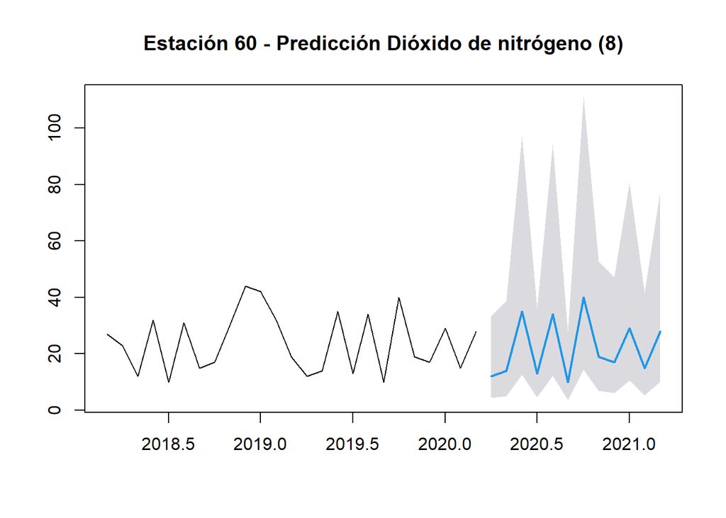

### Plot Comparativo de las valores reales vs valores predichos del Dióxido de nitrógeno(8)

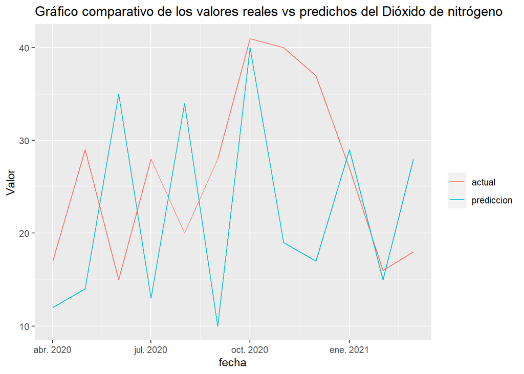

### Elaboración modelo magnitud 10, Particulas <10um, estación 60

```
##
##  ARIMA(2,0,2)(1,1,1)[12] with drift         : Inf
##  ARIMA(0,0,0)(0,1,0)[12] with drift         : 35.97272
##  ARIMA(1,0,0)(1,1,0)[12] with drift         : 37.62663
##  ARIMA(0,0,1)(0,1,1)[12] with drift         : 38.70225
##  ARIMA(0,0,0)(0,1,0)[12]                    : 33.63356
##  ARIMA(0,0,0)(1,1,0)[12] with drift         : 35.52406
##  ARIMA(0,0,0)(0,1,1)[12] with drift         : 36.72795
##  ARIMA(0,0,0)(1,1,1)[12] with drift         : Inf
##  ARIMA(1,0,0)(0,1,0)[12] with drift         : 37.81948
##  ARIMA(0,0,1)(0,1,0)[12] with drift         : 37.68143
##  ARIMA(1,0,1)(0,1,0)[12] with drift         : 40.446
##
##  Best model: ARIMA(0,0,0)(0,1,0)[12]
```

```
## Series: tss_60_10
## ARIMA(0,0,0)(0,1,0)[12]
## Box Cox transformation: lambda= 0
##
## sigma^2 estimated as 0.1878:  log likelihood=-15.74
## AIC=33.47   AICc=33.63   BIC=34.77
##
## Training set error measures:
##                     ME     RMSE      MAE       MPE     MAPE      MASE      ACF1
## Training set 0.6801317 5.892265 3.808337 -6.766323 26.91061 0.6947641 0.2698178
##                     ME     RMSE      MAE       MPE     MAPE      MASE      ACF1
## Training set 0.6801317 5.892265 3.808337 -6.766323 26.91061 0.6947641 0.2698178
```

### Predicción la magnitud 10, Partículas <10um, estación 60

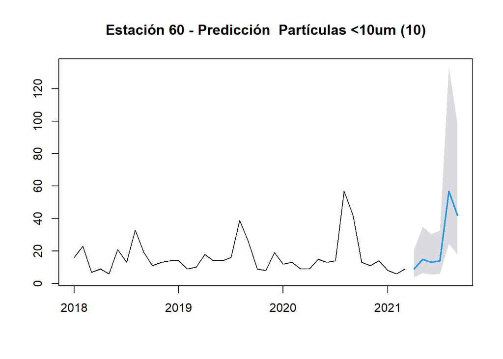

```
##
## Forecast method: ARIMA(0,0,0)(0,1,0)[12]
##
## Model Information:
## Series: tss_60_10
## ARIMA(0,0,0)(0,1,0)[12]
## Box Cox transformation: lambda= 0
##
## sigma^2 estimated as 0.1878:  log likelihood=-15.74
## AIC=33.47   AICc=33.63   BIC=34.77
##
## Error measures:
##                     ME     RMSE      MAE       MPE     MAPE      MASE      ACF1
## Training set 0.6801317 5.892265 3.808337 -6.766323 26.91061 0.6947641 0.2698178
##
## Forecasts:
##          Point Forecast     Lo 95     Hi 95
## Apr 2021              9  3.848832  21.04535
## May 2021             15  6.414719  35.07558
## Jun 2021             13  5.559424  30.39884
## Jul 2021             14  5.987071  32.73721
## Aug 2021             57 24.375934 133.28720
## Sep 2021             42 17.961214  98.21162
```

### Elaboración modelo magnitud 14, Ozono, estación 60

```
##
##  ARIMA(2,0,2)(1,1,1)[12] with drift         : Inf
##  ARIMA(0,0,0)(0,1,0)[12] with drift         : 23.54204
##  ARIMA(1,0,0)(1,1,0)[12] with drift         : 26.29109
##  ARIMA(0,0,1)(0,1,1)[12] with drift         : 26.67248
##  ARIMA(0,0,0)(0,1,0)[12]                    : 21.50968
##  ARIMA(0,0,0)(1,1,0)[12] with drift         : 23.6254
##  ARIMA(0,0,0)(0,1,1)[12] with drift         : 24.06747
##  ARIMA(0,0,0)(1,1,1)[12] with drift         : Inf
##  ARIMA(1,0,0)(0,1,0)[12] with drift         : 26.03625
##  ARIMA(0,0,1)(0,1,0)[12] with drift         : 25.98164
##  ARIMA(1,0,1)(0,1,0)[12] with drift         : Inf
##
##  Best model: ARIMA(0,0,0)(0,1,0)[12]
```

```
## Series: tss_60_14
## ARIMA(0,0,0)(0,1,0)[12]
## Box Cox transformation: lambda= 0
##
## sigma^2 estimated as 0.1199:  log likelihood=-9.67
## AIC=21.35   AICc=21.51   BIC=22.65
##
## Training set error measures:
##                      ME     RMSE      MAE       MPE     MAPE      MASE
## Training set -0.9692425 13.81941 9.235886 -6.615966 19.21426 0.6985124
##                     ACF1
## Training set -0.02903433
##                      ME     RMSE      MAE       MPE     MAPE      MASE
## Training set -0.9692425 13.81941 9.235886 -6.615966 19.21426 0.6985124
##                     ACF1
## Training set -0.02903433
```

### Predicción la maginitud 14, Ozono, estación 60

[figure not shown]

[output not shown]